# Analyzing Real World Fuel efficiency Data

#### Dataset Info:

```python
# import the required libraries

import pandas as pd
import plotly.express as px
import matplotlib.pyplot as plt
import seaborn as sns
```

#### Load the data file and look at some records of the data

```python
df= pd.read_csv('real_world_fuel_efficiency_1.csv')
df
```

|  | year | make | model | hybrid_non_hybrid | standard_type | epa_rating_city | vehicle_count | total_actual_miles | total_actual_fuel | epa_expected_fuel | actual_fuel_economy_geotab | percent_difference_actual_to_epa | estimated_fuel_costs_per_gallon | fuel_costs_per_mile |
| --- | --- | --- | --- | --- | --- | --- | --- | --- | --- | --- | --- | --- | --- | --- |
| 0 | 2008 | HONDA | CIVIC GX | Non-Hybrid | SEDAN | 24 | 9 | 4459 | 221.0 | 185.79 | 20.18 | -0.16 | $ 552.50 | $ 0.12 |
| 1 | 2008 | FORD | CROWN VIC | Non-Hybrid | SEDAN | 11 | 7 | 17162 | 1771.0 | 1560.18 | 9.69 | -0.12 | $ 4,427.50 | $ 0.26 |
| 2 | 2008 | CHEVROLET | EXPRESS | Non-Hybrid | VAN | 13 | 1 | 413 | 65.0 | 31.77 | 6.35 | -0.51 | $ 162.50 | $ 0.39 |
| 3 | 2008 | FORD | FOCUS | Non-Hybrid | SEDAN | 24 | 49 | 13074 | 793.0 | 544.75 | 16.49 | -0.31 | $ 1,982.50 | $ 0.15 |
| 4 | 2008 | FORD | FUSION | Non-Hybrid | SEDAN | 18 | 5 | 29482 | 1813.0 | 1637.89 | 16.26 | -0.10 | $ 4,532.50 | $ 0.15 |
| ... | ... | ... | ... | ... | ... | ... | ... | ... | ... | ... | ... | ... | ... | ... |
| 101 | 2019 | CHEVROLET | EXPRESS | Non-Hybrid | VAN | 13 | 22 | 10316 | 885.0 | 793.54 | 11.66 | -0.10 | $ 2,212.50 | $ 0.21 |
| 102 | 2019 | FORD | F150 | Non-Hybrid | PICKUP | 16 | 27 | 56410 | 5419.0 | 3525.63 | 10.41 | -0.35 | $ 13,547.50 | $ 0.24 |
| 103 | 2019 | FORD | F250 | Non-Hybrid | PICKUP | 12 | 30 | 84521 | 5449.0 | 7043.42 | 15.51 | 0.29 | $ 13,622.50 | $ 0.16 |
| 104 | 2019 | FREIGHTLINER | SPRINTER 3500 | Non-Hybrid | VAN | 15 | 38 | 3277 | 296.0 | 218.47 | 11.07 | -0.26 | $ 740.00 | $ 0.23 |
| 105 | 2019 | FORD | TRANSIT VAN | Non-Hybrid | VAN | 20 | 7 | 29068 | 2331.0 | 1453.40 | 12.47 | -0.38 | $ 5,827.50 | $ 0.20 |

106 rows × 14 columns

#### Check the various attributes of data like shape(rows and columns),columns,datatypes

```python
df.shape
```

```
(106, 14)
```

```python
df.columns.values
```

```
array(['year', 'make', 'model', 'hybrid_non_hybrid', 'standard_type',
       'epa_rating_city', 'vehicle_count', 'total_actual_miles',
       'total_actual_fuel', 'epa_expected_fuel',
       'actual_fuel_economy_geotab', 'percent_difference_actual_to_epa',
       'estimated_fuel_costs_per_gallon', 'fuel_costs_per_mile'],
      dtype=object)
```

#### In the above we can see the format of all the column name is Correct so no need to Change the name of the Columns.

```python
# Checking the data types of all the columns

df.dtypes
```

```
year                                  int64
make                                 object
model                                object
hybrid_non_hybrid                    object
standard_type                        object
epa_rating_city                       int64
vehicle_count                         int64
total_actual_miles                    int64
total_actual_fuel                   float64
epa_expected_fuel                   float64
actual_fuel_economy_geotab          float64
percent_difference_actual_to_epa    float64
estimated_fuel_costs_per_gallon      object
fuel_costs_per_mile                  object
dtype: object
```

- We can see above all the data sets having the correct data types format expect the last two columns that is estimated_fuel_costs_per_gallon and fuel_costs_per_mile but we can not change those data type into correct one reason because those two columns having '$' Signs if we remove those dollor signs then the values present within those two columns will become meaningless, Also it is not going to create any sort of impact upon my analysis.

# Data Cleaning

- For features with very high number of missing values- it is better to drop those columns as they give very less insight on analysis.
- As there is not any specific rule on what criteria do we delete the columns with high number of missing values, but generally you can delete the columns, if you have more than 30-40% of missing values. but again there is a catch here, for example, Is_Car & Car_Type, people having no cars, will obviously have Car_Type as NaN(null), but that does not make this column useless, so decisions has to be taken Wisely.

```python
df.isnull().sum()
```

```
year                                0
make                                0
model                               0
hybrid_non_hybrid                   0
standard_type                       0
epa_rating_city                     0
vehicle_count                       0
total_actual_miles                  0
total_actual_fuel                   0
epa_expected_fuel                   0
actual_fuel_economy_geotab          0
percent_difference_actual_to_epa    0
estimated_fuel_costs_per_gallon     0
fuel_costs_per_mile                 0
dtype: int64
```

### As we don't have any Missing or Null values present inside the entire dataset so, no Data Cleaning is required.

```python
# Checking about duplicated values

df.duplicated().sum()
```

```
0
```

#### Checking the Descriptive Statistics of numeric variables

```python
df.describe()
```

|  | year | epa_rating_city | vehicle_count | total_actual_miles | total_actual_fuel | epa_expected_fuel | actual_fuel_economy_geotab | percent_difference_actual_to_epa |
| --- | --- | --- | --- | --- | --- | --- | --- | --- |
| count | 106.000000 | 106.000000 | 106.000000 | 1.060000e+02 | 106.000000 | 106.000000 | 106.000000 | 106.000000 |
| mean | 2013.698113 | 23.254717 | 38.320755 | 1.742588e+05 | 8470.372642 | 6903.022358 | 19.883491 | -0.166321 |
| std | 3.165799 | 11.495806 | 51.139128 | 2.837817e+05 | 9212.284006 | 7641.761732 | 12.329095 | 0.226229 |
| min | 2008.000000 | 9.000000 | 1.000000 | 4.130000e+02 | 65.000000 | 31.770000 | 5.350000 | -0.670000 |
| 25% | 2011.000000 | 15.000000 | 10.000000 | 3.217475e+04 | 1765.750000 | 1412.797500 | 10.545000 | -0.317500 |
| 50% | 2014.000000 | 19.000000 | 20.500000 | 8.400450e+04 | 5365.500000 | 4511.125000 | 14.930000 | -0.160000 |
| 75% | 2016.000000 | 28.000000 | 45.750000 | 1.800435e+05 | 11911.500000 | 9723.207500 | 26.090000 | -0.040000 |
| max | 2019.000000 | 55.000000 | 327.000000 | 2.144639e+06 | 44874.000000 | 44679.980000 | 54.580000 | 0.730000 |

#### Look at the top 5 records of data below

```python
df.head()
```

|  | year | make | model | hybrid_non_hybrid | standard_type | epa_rating_city | vehicle_count | total_actual_miles | total_actual_fuel | epa_expected_fuel | actual_fuel_economy_geotab | percent_difference_actual_to_epa | estimated_fuel_costs_per_gallon | fuel_costs_per_mile |
| --- | --- | --- | --- | --- | --- | --- | --- | --- | --- | --- | --- | --- | --- | --- |
| 0 | 2008 | HONDA | CIVIC GX | Non-Hybrid | SEDAN | 24 | 9 | 4459 | 221.0 | 185.79 | 20.18 | -0.16 | $ 552.50 | $ 0.12 |
| 1 | 2008 | FORD | CROWN VIC | Non-Hybrid | SEDAN | 11 | 7 | 17162 | 1771.0 | 1560.18 | 9.69 | -0.12 | $ 4,427.50 | $ 0.26 |
| 2 | 2008 | CHEVROLET | EXPRESS | Non-Hybrid | VAN | 13 | 1 | 413 | 65.0 | 31.77 | 6.35 | -0.51 | $ 162.50 | $ 0.39 |
| 3 | 2008 | FORD | FOCUS | Non-Hybrid | SEDAN | 24 | 49 | 13074 | 793.0 | 544.75 | 16.49 | -0.31 | $ 1,982.50 | $ 0.15 |
| 4 | 2008 | FORD | FUSION | Non-Hybrid | SEDAN | 18 | 5 | 29482 | 1813.0 | 1637.89 | 16.26 | -0.10 | $ 4,532.50 | $ 0.15 |

```python
# Concise Summary of the dataframe

df.info()
```

```
<class 'pandas.core.frame.DataFrame'>
RangeIndex: 106 entries, 0 to 105
Data columns (total 14 columns):
 #   Column                            Non-Null Count  Dtype
---  ------                            --------------  -----
 0   year                              106 non-null    int64
 1   make                              106 non-null    object
 2   model                             106 non-null    object
 3   hybrid_non_hybrid                 106 non-null    object
 4   standard_type                     106 non-null    object
 5   epa_rating_city                   106 non-null    int64
 6   vehicle_count                     106 non-null    int64
 7   total_actual_miles                106 non-null    int64
 8   total_actual_fuel                 106 non-null    float64
 9   epa_expected_fuel                 106 non-null    float64
 10  actual_fuel_economy_geotab        106 non-null    float64
 11  percent_difference_actual_to_epa  106 non-null    float64
 12  estimated_fuel_costs_per_gallon   106 non-null    object
 13  fuel_costs_per_mile               106 non-null    object
dtypes: float64(4), int64(4), object(6)
memory usage: 11.7+ KB
```

# Data Exploration

### Bivariate Analysis

```python
fig1= px.bar(df,x='year',y='vehicle_count',title=' Year wise Vehicles Count per Company',hover_name='hybrid_non_hybrid',color='make',height=500)

fig1.show()
```

[interactive chart not shown]

```python
fig2= px.line(df,x='year',y='fuel_costs_per_mile',color='make',height=500,title='Yearly fuel Costs per Mile between 2008 to 2019')

fig2.show()
```

[interactive chart not shown]

```python
fig3= px.bar(df, x='make',y='epa_rating_city', color='year',title='Vehicles and their epa rating of the new york city from 2008 to 2019',hover_name='model',animation_frame='standard_type',height=600)

fig3.show()
```

[interactive chart not shown]

```python
fig4= px.scatter(df, x='total_actual_fuel', y='epa_expected_fuel',title='Relationship between total_actual_fuel and epa_expected_fuel')

fig4.show()
```

[interactive chart not shown]

```python
fig8= px.bar(df,x='year',y='total_actual_miles',title=' Year wise total_actual_miles of different vehicles',color='make',height=500)

fig8.show()
```

[interactive chart not shown]

```python
# if we want to see all data of only GMC(General Motors)company then we can find using the Loc method below.

df.loc[df.make=='GMC']
```

|  | year | make | model | hybrid_non_hybrid | standard_type | epa_rating_city | vehicle_count | total_actual_miles | total_actual_fuel | epa_expected_fuel | actual_fuel_economy_geotab | percent_difference_actual_to_epa | estimated_fuel_costs_per_gallon | fuel_costs_per_mile |
| --- | --- | --- | --- | --- | --- | --- | --- | --- | --- | --- | --- | --- | --- | --- |
| 69 | 2015 | GMC | YUKON | Non-Hybrid | SUV | 15 | 9 | 10417 | 1064.0 | 694.47 | 9.79 | -0.35 | $ 2,660.00 | $ 0.26 |
| 70 | 2015 | GMC | YUKON XL | Non-Hybrid | SUV | 15 | 84 | 25690 | 2179.0 | 1712.67 | 11.79 | -0.21 | $ 5,447.50 | $ 0.21 |

# Univariate Analysis

```python
fig5= px.pie(df,values='actual_fuel_economy_geotab',names='make',height=400,title='vehicles having actual_fuel_economy according to Geotab')

fig5.show()
```

[interactive chart not shown]

```python
fig6= px.box(df,y='estimated_fuel_costs_per_gallon',color='hybrid_non_hybrid',height=500, title='estimated_fuel_costs_per_gallon according to Hybrid and Non hybrid Engines')

fig6.show()
```

[interactive chart not shown]

## Multivariate analysis

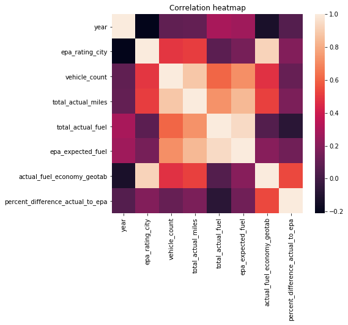

```python
plt.figure(figsize=(7,6))
sns.heatmap(df.corr())
plt.title('Correlation heatmap')
plt.show()
```